# Business Analytics: Customer segmentation using $K$-means

### "*Everyone is not your customer.*" — Seth Godin

# Introduction

Customer segmentation is one of the most successful applications of Machine Learning (ML), in partciular unsupervised ML, for business and marketing analytics. With the abundance of customer data gathered by companies, either through third-party vendors (e.g. cookies) or by using their own CRM software, it is finally possible to start exploring the customer profiles in depth and identifying behavioural patterns and traits of customers. Customer profiling helps companies target with precision specific subsets of their customer base to boost growth, increase revenues and ensure long-term customer loyalty.

Clustering is the scientific concept behind customer segmentation and is still (and probably will continue to be) an open field of research. Unfortunately, there is no one recipe for performing cluster analysis. Is is rather an iterative process that combines rigorous knowledge of Machine Learning, business accumen, and an open-mind for exploration.

In the following report we will dive into the following topics:

- How to perform K-means unsing scikit learn
- Theoretical background behind K-means
- Useful parameters and attributes of scikit learn's `KMeans`
- Heuristics to choose the best value for **K**
  - Elbow Method
  - Rules of Thumb (used in practice)
  - Silhoutte Plot
- 3D (and 2D) Visualisation of Clusters
- Cluster interpretation

AND:

- **2 Business Case Studies**
  1. Where to look for potential customers? (customer acquisition)
  2. How to reward the top performing customers? (customer retention)

# 0. Import libraries and functions

```python
import numpy as np
import pandas as pd
import matplotlib.pyplot as plt

from sklearn.cluster import KMeans
from sklearn.metrics import silhouette_samples, silhouette_score

import warnings
warnings.filterwarnings('ignore')
```

# 1. Import, explore and scale dataset

## 1.1 Read and preview dataset

We start the process by importing the data set.

```python
customers = pd.read_csv("customers.csv")
```

```python
customers.head()
```

|  | ID | Gender | Age | Income | Score |
| --- | --- | --- | --- | --- | --- |
| 0 | 1 | Male | 19 | 15 | 39 |
| 1 | 2 | Male | 21 | 15 | 81 |
| 2 | 3 | Female | 20 | 16 | 6 |
| 3 | 4 | Female | 23 | 16 | 77 |
| 4 | 5 | Female | 31 | 17 | 40 |

In this dataset each row represents a customer, and four different attributes are provided for each. Specifically, we have knowledge of the customer's **Gender** (male/female), **Age**, **Income** status and (spending) **Score**. To get a quick overview of our customer base, we can take a look at some summary statistics.

## 1.2 Explore dataset (Summary statistics)

To get an idea of the available customer features and their numerical values, we use the built in method `.describe()` and obtain some summary statistics.

```python
customers.drop(columns=['ID']).describe()
```

|  | Age | Income | Score |
| --- | --- | --- | --- |
| count | 200.000000 | 200.000000 | 200.000000 |
| mean | 38.850000 | 60.560000 | 50.200000 |
| std | 13.969007 | 26.264721 | 25.823522 |
| min | 18.000000 | 15.000000 | 1.000000 |
| 25% | 28.750000 | 41.500000 | 34.750000 |
| 50% | 36.000000 | 61.500000 | 50.000000 |
| 75% | 49.000000 | 78.000000 | 73.000000 |
| max | 70.000000 | 137.000000 | 99.000000 |

```python
print('Percentage of female customers:', str(round((customers['Gender']=='Female').sum()/len(customers)*100,2)) + '%')
```

```
Percentage of female customers: 56.0%
```

By looking at the table, we immediately recognize that we have data for **200 customers** and **no missing values**. Our customer database is more or less balanced in terms of gender, with 56% of customers being female. The mean age is around **39 years old**, with three quarters of all customers being under 50. The average income level is around **60,56 units (we presume it is measured in $1000s)** with 75\% of people earning just under 80 units. The **spending score** is confined between 0 and 100 and has an mean a value of approximately **50** units. The last step before conducting a cluster analysis, is to scale the features to make sure all of them are on a similar scale.

## 1.3 Scale attributes: Age, Income, Score

$K$-means, just like most of the clustering techniques used in practice, uses a distance function to measure the similarity between data points (customers in this case). Because features are measured on different scales, we will normalise the features, so that all of them bear equal weight in the distance calculation. To do that, we subract from each feature value the feature's mean value over all customers and then divide by the standard deviation (Z-scale/normalisation). By doing so, each numerical value will now represent the number of standard deviations it deviates from the feature's mean value over all customers. We will apply the Z-score normalisation on Age, Income and Score, using the `StandardScaler` class from `scikit learn`.

```python
from sklearn.preprocessing import StandardScaler

scaler = StandardScaler() # instantiate a scaler object
scaler.fit(customers[['Income', 'Age', 'Score']]) # calculate the mean value and standard deviation for each feature
customers_sc = scaler.transform(customers[['Income', 'Age','Score']]) # apply Z-normalisation. Returns an array
customers_sc_df = pd.DataFrame(customers_sc, columns=['Income', 'Age','Score']) # create a df from the array
```

```python
customers_sc_df.head(3) # print the df
```

|  | Income | Age | Score |
| --- | --- | --- | --- |
| 0 | -1.738999 | -1.424569 | -0.434801 |
| 1 | -1.738999 | -1.281035 | 1.195704 |
| 2 | -1.700830 | -1.352802 | -1.715913 |

# 2. Clustering using $K$-means

## 2.1 Introduction

In this section will deploy the K-means algorithm on customer data using the `KMeans` class from `scikit-learn`. We will experiment with various values for $K$ and resort to a number of techniques to choose the best one. As clustering is an unsupervised task, there is no (one) easy or straightforward mathematical method to determine the best value for $K$ (see Section 2.2). Therefore, we will have to employ business reasoning and knowledge along some heuristics and algorithms (elbow method, rule of thumb) to choose the value that seems to provide the most insight into the customer base. For the most part of this analysis, only Age, Income and Score will be considered. Gender will be taken into account in Section 5.

We first import `KMeans` from `sklearn.cluster`

```python
from sklearn.cluster import KMeans
```

## 2.2 $K$-means main code

In the following code snippet, we run $K$-means for $K \in [1,15]$ and store the **inertia** metric for each $K$ value. In effect the measure of inertia sums up the squred distance of each point to its assigned cluster centroid. Evidently, as we increase the number of clusters, this distance to the centroid will shrink. If we set $K=n$, where $n$ is the number of data points/customers, inertia will be 0, as each point is a centroid and has 0 distance to itself. This highlights an important issue. Unlike in supervised learning, where the best value of a hyperparameter is derived by minimising the validation error, in unsupervised tasks, there is no such tool. The number of clusters must be determined with other metrics in mind, which we will discuss in Section 2.3

Definiton of Inertia: $\sum_{i=0}^{n}{\min\limits_{\mu_j \in C} ||x_i - \mu_j||^2}$, where $\mu_j$ are the cluster centroids, and $C$ is the set of all centroids and $x_i$ is a data point. $K$-means is a heuristic that aims to minimise this problem (NP-hard problem)

```python
distances_init = [] # list that will contain the inertia metric for each K value

X = customers_sc_df[[ 'Income', 'Age', 'Score']].values # array with 3 feature values

k_range = 15 # we will implement clustering for K ranging from 1 to 15

# Main Loop
for k in range(1,k_range+1):

    kmeans = KMeans(n_clusters=k, n_init=100) #Instantiate K-means object, specify the number of clusters and
                                              # number of initialisations, i.e., the number of runs for a single value of K
    kmeans.fit(X)

    distances_init.append(kmeans.inertia_)
```

## 2.3 Plot Elbow Chart

We now plot inertia over $K$. The idea of the elbow chart is based on the shape of the curve. In the beginning, $K$ increases, there is a significant reduction in Inertia, signaling that the additional clusters are grouping the data points better together. After a threshold value for $K$, the elbow, the marginal reduction in inertia stabilizes. This is usually a sign that we are adding clusters which probably do not exist in the data. Thus, the elbow method proposes choosing $K$ at the point where the marginal intertia reductions stabilizes.

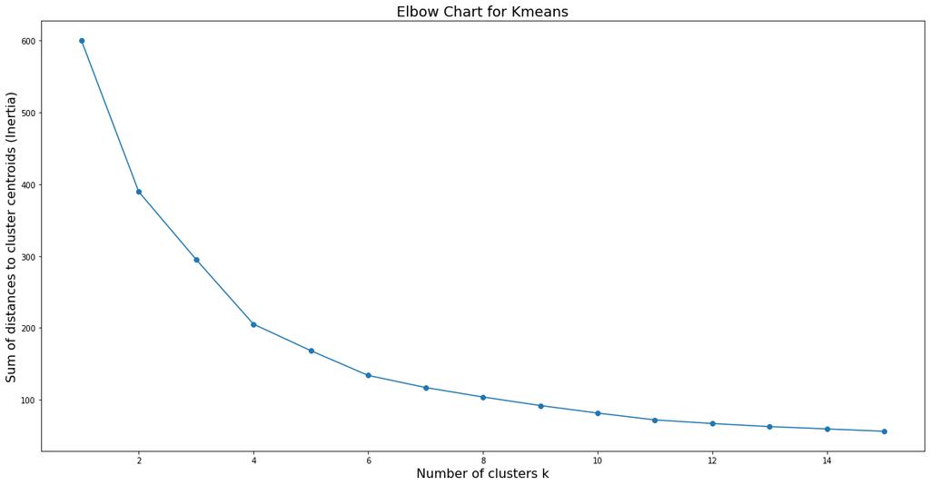

```python
plt.rcParams["figure.figsize"] = (20,10)
plt.plot(range(1,k_range+1),distances_init, marker='o')
plt.title('Elbow Chart for Kmeans', fontsize=18)
plt.ylabel('Sum of distances to cluster centroids (Inertia)', fontsize=16)
plt.xlabel('Number of clusters k', fontsize=16)
```

## 2.4 Theory: Why can we trust the elbow plot?

### 2.4.1 K-means is a heuristic method to an NP-hard problem

K-means is only a heuristic method of clustering, i.e., it does not prove optimality of the obtained clusters. While it is guaranteed that the value of the objective function, i.e., the sum of squared distances from every data point to its current cluster, will decrease monotonically as the algorithm progresses, the minimum value achieved after convergence generally depends on the initial assigment of cluster centroids. In other words, for the same number of pre-specified clusters $K$, the value of $\sum_{i=0}^{n}{\min_{\mu_j \in C} ||x_i - \mu_j||^2}$ may differ depending on the initial centroids.

## 2.5 Silhoutte Plot

Silhoutte Plot is another heuristic for determining a good number of clusters for the data. It is based on the idea of calculating (for each data point) the ratio of the difference between the minimum average distance of a point to the points of another cluster and the average distance of all other points in the same cluster, to the maximum of either values. Silhoutte values range between [-1,1] with -1 meaning that the average distance to points in another clusters is shorter than the one it has to points within its current cluster, and values closer to 1 being the strongest indication that it belongs to the right cluster. Values near 0 indicate that a point is probably on the boarder between two clusters.

### 2.5.1 Average Silhoutte Score for $K \in [4,5,6,7,8]$

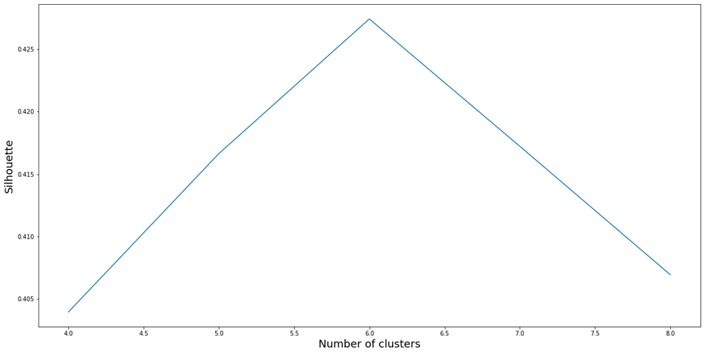

```python
# Select number of clusters based on Silhoutte
fig, ax = plt.subplots()
cluster_nums = [4, 5, 6, 7, 8]
silhouettes = []

for n_clusters in cluster_nums:
    kmeans = KMeans(n_clusters=n_clusters)
    kmeans.fit_predict(X)
    labels = kmeans.labels_
    silhouettes.append(silhouette_score(X, labels)) #  average silhoute value over all points for given K
ax.plot(cluster_nums, silhouettes)
ax.set_xlabel("Number of clusters", fontsize= 18)
ax.set_ylabel("Silhouette", fontsize=18)
```

### 2.5.2 Silhoutee Plot for $K$=6

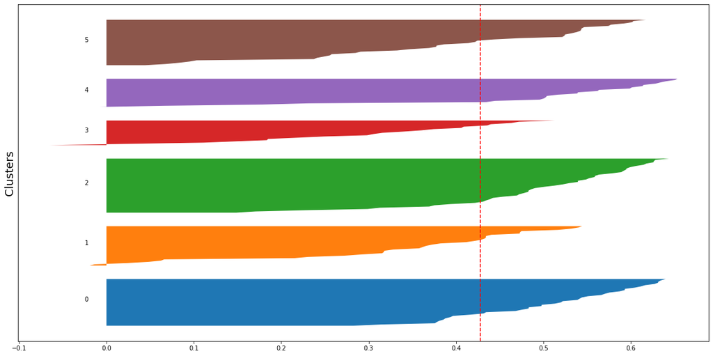

```python
# Silhouette plot for K = 6
kmeans = KMeans(n_clusters= 6, n_init=100)
kmeans.fit(X)
labels = kmeans.labels_
centers = kmeans.cluster_centers_

silhouette = silhouette_score(X, labels)

silhouette_values = silhouette_samples(X, labels)
fig, ax = plt.subplots()
y_lower = 10
for i in range(len(kmeans.cluster_centers_)):
    ith_cluster_silhouette_values = silhouette_values[labels == i]
    ith_cluster_silhouette_values.sort()
    size_cluster_i = ith_cluster_silhouette_values.shape[0]
    y_upper = y_lower + size_cluster_i
    ax.fill_betweenx(np.arange(y_lower, y_upper), 0, ith_cluster_silhouette_values)
    ax.text(-0.025, y_lower + 0.5 * size_cluster_i, str(i))
    y_lower = y_upper + 10
ax.axvline(x=silhouette, color="red", linestyle="--")
ax.set_yticks([])
ax.set_ylabel("Clusters", fontsize=18)
```

As we can see, even for $K$=6, there are points with negative silhoutte coefficients. The red line describes the average silhoutte score of all data point for $K$=6 (the same score seen in the previous plot). The two methods (Elbow and Silhoutte) are suggesting different "optimal" values for $K$. We will eventually see that a business case/context helps decide the optimal value for $K$.

## 2.6 Choosing the best $K$ value (what indications do we have so far?)

- **Elbow method**: Identify the number of clusters after which the reduction in inertia/sum of squared distances to centroids stabilizes. The elbow point appears to be closer to $K$=4 or 5
- **Sihloutte method**: $K$=6 is suggested based on (average) Silhoutte scores.
- **Rule of Thumb** (used in practice as starting point) : $K = \sqrt{n/2}$, $k = \sqrt{200/2} = \sqrt{100} = 10$ clusters.
- **Domain specific knowledge**: It will be useful to plot the result for $K=6$ and then also try some values towards $K$=10, to evaluate whether we get more representative clusters. We thus try $K$=7 and $K$=8 as wel and see which option offers the most interpretable segments.

## 2.7 Theory: Initialisation of centroids in scikit learn's `KMeans` implementation

For scikit learn's implementation of K-means, one can experiment with different initialisation states for the cluster centroids using the two parameters, `init` and `n_init`, from the `KMeans` class.

### 2.7.1 `init` parameter: Centroid initialisation mechanisms

The first parameter, `init`, determines the generation procedure for the initial centroids. There are two processes impleneted in scikit learn's `Kmeans` class. The first mechanism is *'random'*, according to which, $K$ centroids are selected randomly from the available data points. The second mechanism, *'kmeans++'*, uses weighted probabilities to select the initial cluster centroids. It has been shown that *'kmeans++'* improves the convergence rate and robustness of the clusters formed. The process starts with selecting the first initial centroid at random and then assigns a higher probability of being selected as the next centroid, to the most distant points from the current centroid(s). The previous step is repeated $K-1$ times until $K$ centroids have been selected. Using this method, the centroids obtained are more distant compared to those generated by the *'random'* mechanism and provide (most of the times) faster and more accurate results. `Kmeans` uses *kmeans++* as the default centroid initiaslisation process.

### 2.7.2 `n_init` parameter: Multiple centroid initialisations

Using `n_init`, one can set the number of different centroid initialisations that will be computed by the `Kmeans` classifier for a specific value of $K$. Only the one providing the lowest sum of squared distances to centroids will be retured which is in accordance with the analysis we did in the previous sections.

# 3. 3D Visualisation

### 3.1 Get clusters for $K \in [4,6,7,8]$

```python
kmeans_4 = KMeans(n_clusters=4, n_init = 100)
kmeans_6 = KMeans(n_clusters=6, n_init = 100)
kmeans_7 = KMeans(n_clusters=7, n_init = 100)
kmeans_8 = KMeans(n_clusters=8, n_init = 100)

kmeans_4.fit(X)
kmeans_6.fit(X)
kmeans_7.fit(X)
kmeans_8.fit(X)

print('Inertia for K=4:', kmeans_4.inertia_)
print('Inertia for K=6:', kmeans_6.inertia_)
print('Inertia for K=7:', kmeans_7.inertia_)
print('Inertia for K=8:', kmeans_8.inertia_)
```

```
Inertia for K=4: 205.22514747675916
Inertia for K=6: 133.86833362685582
Inertia for K=7: 117.01155455889811
Inertia for K=8: 103.82586112157725
```

## 3.2 Descale/Denormalise centroid coordinates

We use `.inverse_transform()` method, which is built in scikit learn

```python
kmeans_4_cents_descld = scaler.inverse_transform(kmeans_4.cluster_centers_)
kmeans_6_cents_descld = scaler.inverse_transform(kmeans_6.cluster_centers_)
kmeans_7_cents_descld = scaler.inverse_transform(kmeans_7.cluster_centers_)
kmeans_8_cents_descld = scaler.inverse_transform(kmeans_8.cluster_centers_)
```

## 3.3 3D Plotting

### 3.3.1 Data preprocessing (for plotting)

1. Concatenate the three features (Income, Age, Score) values with the denormalised centroid coordinates. The first positions in the resulting array correspond to the centroid positions
2. Concatenate the centroid labels with the labels array (`kmeans.labels_`)
3. Create a consistent colormap

#### 1 and 2. Concatenate centroid coordinates with feature values in one array and centroid labels with predicted labels

```python
# K=4
Income_4 = np.concatenate((kmeans_4_cents_descld.T[0],customers['Income'].values))
Age_4 = np.concatenate((kmeans_4_cents_descld.T[1],customers['Age'].values))
Score_4 = np.concatenate((kmeans_4_cents_descld.T[2],customers['Score'].values))
labels_4 = np.concatenate((np.arange(4), kmeans_4.labels_))

# K=6
Income_6 = np.concatenate((kmeans_6_cents_descld.T[0],customers['Income'].values))
Age_6 = np.concatenate((kmeans_6_cents_descld.T[1],customers['Age'].values))
Score_6 = np.concatenate((kmeans_6_cents_descld.T[2],customers['Score'].values))
labels_6 = np.concatenate((np.arange(6), kmeans_6.labels_))
#K=7
Income_7 = np.concatenate((kmeans_7_cents_descld.T[0],customers['Income'].values))
Age_7 = np.concatenate((kmeans_7_cents_descld.T[1],customers['Age'].values))
Score_7 = np.concatenate((kmeans_7_cents_descld.T[2],customers['Score'].values))
labels_7 = np.concatenate((np.arange(7), kmeans_7.labels_))
#K=8
Income_8 = np.concatenate((kmeans_8_cents_descld.T[0],customers['Income'].values))
Age_8 = np.concatenate((kmeans_8_cents_descld.T[1],customers['Age'].values))
Score_8 = np.concatenate((kmeans_8_cents_descld.T[2],customers['Score'].values))
labels_8 = np.concatenate((np.arange(8), kmeans_8.labels_))
```

#### 3. Colormap

```python
colors = {0:'red', 1:'blue', 2: 'brown', 3:'purple', 4:'black', 5:'green', 6:'orange', 7:'pink', 8:'lightgreen'}
```

### 3.3.2 Do the plot

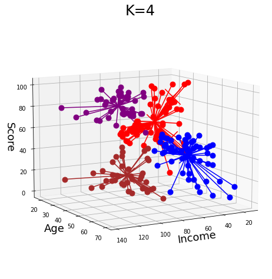

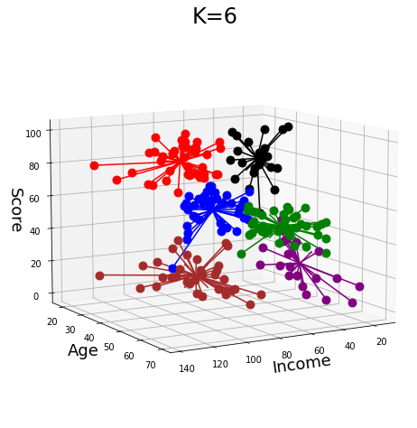

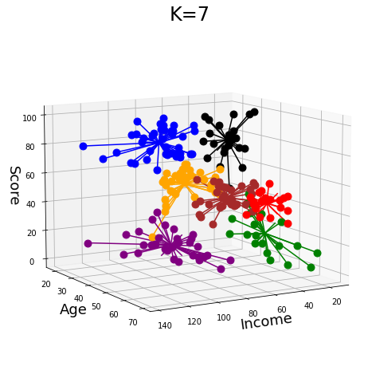

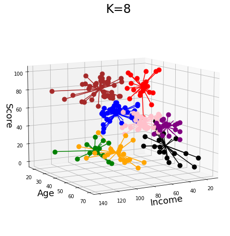

```python
# PLOT FOR K = 4
fig4 = plt.figure(figsize=(15,8))
ax4 = fig4.add_subplot(projection='3d')

for i in range(len(labels_4)):
    if i <= 5:
         # draw centroids bigger and with an 'x'
        ax4.scatter(Income_4[i], Age_4[i], Score_4[i], c = colors[labels_4[i]] , s=700, marker='x')
    else:
        # draw rest of the points as smaller dots
        ax4.scatter(Income_4[i], Age_4[i], Score_4[i], c = colors[labels_4[i]] , s=80)

    # draw the lines connecting each point to each centroid
    ax4.plot([Income_4[i], kmeans_4_cents_descld.T[0][labels_4[i]]],
            [Age_4[i], kmeans_4_cents_descld.T[1][labels_4[i]]],
            [Score_4[i], kmeans_4_cents_descld.T[2][labels_4[i]]],
            c = colors[labels_4[i]])

# Titles, legends etc.
ax4.set_xlabel('Income', fontsize=18)
ax4.set_ylabel('Age', fontsize=18)
ax4.set_zlabel('Score', fontsize=18)
ax4.set_title('K=4', fontsize=24)

# 3D views
ax4.view_init(10,60)


# PLOT FOR K = 6
fig6 = plt.figure(figsize=(15,8))
ax6 = fig6.add_subplot(projection='3d')
for i in range(len(labels_6)):

    if i <= 5:
        ax6.scatter(Income_6[i], Age_6[i], Score_6[i], c = colors[labels_6[i]] , s=700, marker='x')
    else:
        ax6.scatter(Income_6[i], Age_6[i], Score_6[i], c = colors[labels_6[i]] , s=80)

    ax6.plot([Income_6[i], kmeans_6_cents_descld.T[0][labels_6[i]]],
            [Age_6[i], kmeans_6_cents_descld.T[1][labels_6[i]]],
            [Score_6[i], kmeans_6_cents_descld.T[2][labels_6[i]]],
            c = colors[labels_6[i]])

ax6.set_xlabel('Income', fontsize=18)
ax6.set_ylabel('Age', fontsize=18)
ax6.set_zlabel('Score', fontsize=18)
ax6.set_title('K=6', fontsize=24)
ax6.view_init(10,60)


# PLOT FOR K =7
fig7 = plt.figure(figsize=(15,8))
ax7 = fig7.add_subplot(projection='3d')
for i in range(len(labels_7)):

    if i <= 6:
        ax7.scatter(Income_7[i], Age_7[i], Score_7[i], c = colors[labels_7[i]] , s=700, marker='x')
    else:
        ax7.scatter(Income_7[i], Age_7[i], Score_7[i], c = colors[labels_7[i]] , s=80)

    ax7.plot([Income_7[i], kmeans_7_cents_descld.T[0][labels_7[i]]],
            [Age_7[i], kmeans_7_cents_descld.T[1][labels_7[i]]],
            [Score_7[i], kmeans_7_cents_descld.T[2][labels_7[i]]],
            c = colors[labels_7[i]])
ax7.set_xlabel('Income', fontsize=18)
ax7.set_ylabel('Age', fontsize=18)
ax7.set_zlabel('Score', fontsize=18)
ax7.set_title('K=7', fontsize=24)
ax7.view_init(10,60)


## PLOT FOR K = 8
fig8 = plt.figure(figsize=(15,8))
ax8 = fig8.add_subplot(projection='3d')
for i in range(len(labels_8)):

    if i <= 7:
        ax8.scatter(Income_8[i], Age_8[i], Score_8[i], c = colors[labels_8[i]] , s=700, marker='x')
    else:
        ax8.scatter(Income_8[i], Age_8[i], Score_8[i], c = colors[labels_8[i]] , s=80)

    ax8.plot([Income_8[i], kmeans_8_cents_descld.T[0][labels_8[i]]],
            [Age_8[i], kmeans_8_cents_descld.T[1][labels_8[i]]],
            [Score_8[i], kmeans_8_cents_descld.T[2][labels_8[i]]],
            c = colors[labels_8[i]])

ax8.set_xlabel('Income', fontsize=18)
ax8.set_ylabel('Age', fontsize=18)
ax8.set_zlabel('Score', fontsize=18)
ax8.set_title('K=8',fontsize=24)
ax8.view_init(10,60)
```

## 3.4 2D views of 3D plot (better for identifying the clusters)

### 3.4.1 Income-Age: 1st 2D view (Not very informative)

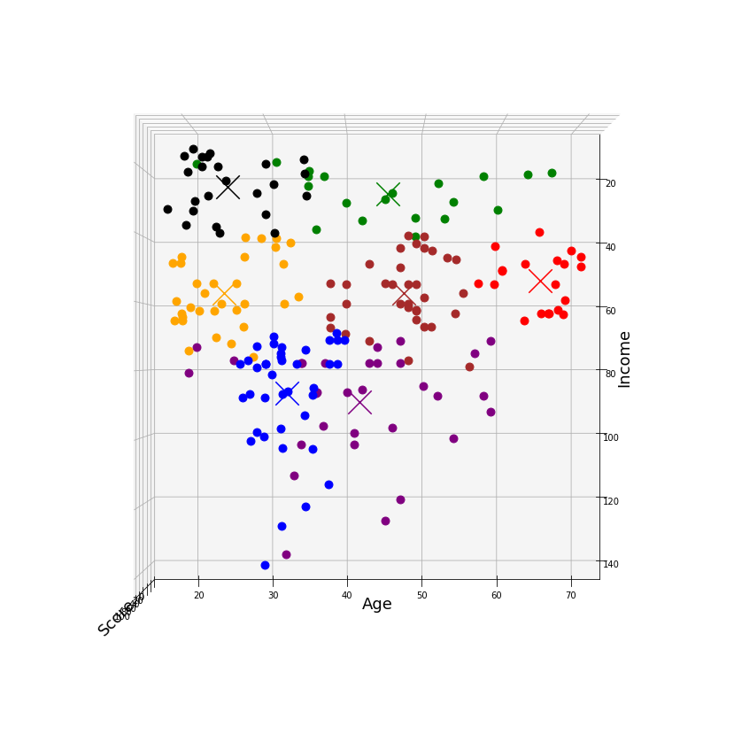

```python
fig = plt.figure(figsize=(25,15))
ax = fig.add_subplot(projection='3d')
for i in range(len(labels_7)):
    if i <= 6:
        ax.scatter(Income_7[i], Age_7[i], Score_7[i], c = colors[labels_7[i]] , s=700, marker='x')
    else:
        ax.scatter(Income_7[i], Age_7[i], Score_7[i], c = colors[labels_7[i]] , s=80)

ax.set_xlabel('Income', fontsize=18)
ax.set_ylabel('Age', fontsize=18)
ax.set_zlabel('Score', fontsize=18)
ax.view_init(90,0)
```

This view does not seem to be informative enough. We will end up using the other two views to describe the resulting clusters.

### 3.4.2 Score-Age: 2nd 2D view (Informative)

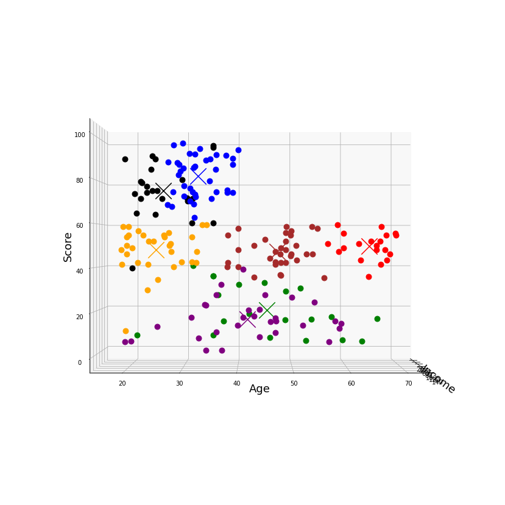

```python
fig = plt.figure(figsize=(25,15))
ax = fig.add_subplot(projection='3d')
for i in range(len(labels_7)):
    if i <= 6:
        ax.scatter(Income_7[i], Age_7[i], Score_7[i], c = colors[labels_7[i]] , s=700, marker='x')
    else:
        ax.scatter(Income_7[i], Age_7[i], Score_7[i], c = colors[labels_7[i]] , s=80)

ax.set_xlabel('Income', fontsize=18)
ax.set_ylabel('Age', fontsize=18)
ax.set_zlabel('Score', fontsize=18)
ax.view_init(0,0)
```

### 3.4.3 Score-Income: 3rd 2D view (Informative)

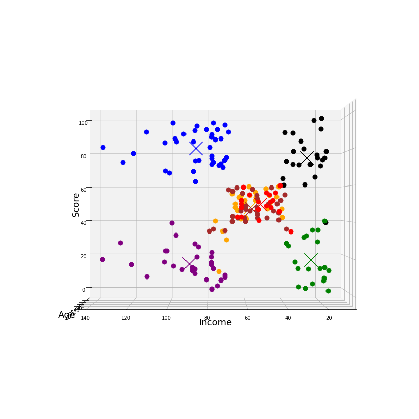

```python
fig = plt.figure(figsize=(25,15))
ax = fig.add_subplot(projection='3d')
for i in range(len(labels_7)):
    if i <= 6:
        ax.scatter(Income_7[i], Age_7[i], Score_7[i], c = colors[labels_7[i]] , s=700, marker='x')
    else:
        ax.scatter(Income_7[i], Age_7[i], Score_7[i], c = colors[labels_7[i]] , s=80)

ax.set_xlabel('Income', fontsize=18)
ax.set_ylabel('Age', fontsize=18)
ax.set_zlabel('Score', fontsize=18)
ax.view_init(0,90)
```

## 3.5 Cluster details

**Low Score performers**

## 3.6 Customer segment analysis

### Introduction

Using the $K$=7, we will describe the clusters identified by the K-means algorithm.

### Score performance

We will use the score metric to describe the customer segments formed with the K-means algorithm. While one can use Age or Income to create a similar structure to the one we will follow in the next sections, we assumed that it is more natural for a company to be studying its customers based on a consumption/bying score. That way, it is easier to track and identify which customers it should target and what their charactersistics are. There appear to be **three different tiers of performance concerning the score metric**, namely high, middle and low. In the following subsections, we will describe the cluster characteristics, as well as similarities and differences among the groups in each score tier.

#### Middle score

Three different clusters fall into the category of middle performance score. All these groups have two very specific traits in common. For one, they are exhibiting strongly similar score behaviour, with two of the groups having a mean score of roughly 49, while the third group has a mean of 47. Secondly, all groups are in the same income bracket (roughly between 40 and 65) units. These three groups cover almost the full age spectrum, with one group containing members aged between 15 and 35, the second between 35 and 55, and the third 55+. The middle score performers seem to be representing the average customer, who earns an average salary.

#### Low score

Depending on whether we set $K=7$ or $K=8$, there appear to be either 2 or 3 clusters of customers in the low score tier (<40). One group differentiates itself completely from the other two due to very low income (strictly <40 units, average of roughly 26 units) obtained by its members. In this group there are people of multiple ages, ranging from 20 to 68. The mean score is about 19 units. As a result, this cluster tends to represent the low income, low score customers of all ages, namely those who have a low economic status and consume/buy considerably less than others.

The other two groups (one if $K=7$ and two if $K=8$) also have low mean scores of 13 and 19, but they both exhibit high income levels of 89 and 88 units on average. These two groups differ slightly in the age spectrum, with an average of 31 and 49 respectively. The younger cluster contains 14 customers aged between 15 and 40 and the older one 20 customers aged between 40 and 60. We remind the reader that both of these groups exhibit similar (and high) income levels. It shall be noted that if $K=7$ is used, these two last clusters are merged together erasing the additional age differentiation between them.

## 3.7 Business Insights: 2 case studies

### 1. Where to look for potential customers?

Companies often perform customer segmentation to identify groups of customers that could potentially increase their customer score (proxy for consumption/buying value for the company), given some additional incentives. In this case, the most attractive customer clusters are the two groups with high income levels and very low mean score. In this case, using $K=8$ is preferential, because we get two clusters instead of 1 when $K=7$ that are further differentiated by age. On one hand, the older group contains more customers (20), thus whatever targeting activity the company undertakes, there is a higher expected number of converted customers, given equal probability of conversion between the two groups. On the other hand, both groups in the highest score tier are groups containing younger people, namely people aged closer to the low-performing customers in the young cluster under study. Given that the population difference between the two low-performing groups is not dramatic, the company should probably consider targeting the younger group first!

### 2. How to reward the top performing customers?

Many companies believe in rewarding their top performing customers to ensure/promote customer loyalty in the long run, especially when new competitors are emerging. In that scenario, the segmentation process is very useful in identifying customer groups with the high scores, and their characteristics. Using the segmentation analysis in the previous section, the company now knows about the two top-performing customer clusters and that these consist mainly of younger people (all <40 years, and 26 and 33 years old on average for the two groups). Thus the company should target the services/products that younger people prefer/ pay for, and specifically the services/products that the customers in these two groups are choosing. On top of that, one of the two groups is in the lowest income bracket, while the other in the highest. In that sense, the company should probably conduct further research to establish whether the two groups perfer the same products or not, and consider rewarding them with differentiated/appropriate incentives to ensure customer loyalty.

## 3.8 Differences in clusters between $K$ = 6,7,8

Starting from the identified clusters with $K$=7, we can recognize that removing one cluster ($K$=6) leads to the merging of two groups in the mid Income - mid Score region. Depending on the business context this might be wanted or not. In our case, the two business cases outlined, do not make use of the mid segments and thus merging two into one would not change the course of action for the company. However, raising $K$ to 8 leads to a further segmentation of the high-Income - low Score group into two, based on the age profiles. That could be very useful, given that buying preferences could vary significantly with age. Since the company is aiming to approach these people with various incentives, it would be wise to differantiate those according to the spending profiles of each age segment. For this reason, we believe that $K=8$ is a better option for the given business context.

# 4. Clustering using only 2 out 4 features

## 4.1 Create the datasets

- `age_income`: dataset for Age-Income
- `age_score`: dataset for Age-Score
- `income_score`: dataset for Income-Score

```python
age_income = customers_sc_df[['Age', 'Income']]
age_score = customers_sc_df[['Age','Score']]
income_score = customers_sc_df[['Income', 'Score']]
```

## 4.2 Run $K$-means for various k values for all three datasets

- `kemans_ai`: $K$-means for *age_income* dataset
- `kemans_as`: $K$-means for *age_score* dataset
- `kemans_is`: $K$-means for *income_score* dataset

```python
data = {}
data['age_income'] = []
data['age_score'] = []
data['income_score'] = []

for k in range(1,k_range+1):
    kmeans_ai = KMeans(n_clusters= k, n_init=100)
    kmeans_ai.fit(age_income)
    data['age_income'].append(kmeans_ai.inertia_)


    kmeans_as = KMeans(n_clusters= k, n_init=100)
    kmeans_as.fit(age_score)
    data['age_score'].append(kmeans_as.inertia_)


    kmeans_is = KMeans(n_clusters= k, n_init=100)
    kmeans_is.fit(income_score)
    data['income_score'].append(kmeans_is.inertia_)
```

## 4.2 Elbow Charts

In the following sections, we will inspect how the segmentation works when using 2 features at a time. As we will see, the process is not as insightful as taking all three into account simultaneously.

### 4.2.1 Elbow Chart for Age-Income

```python
kmeans_ai_final = KMeans(n_clusters= 4, n_init=100)
kmeans_ai_final.fit(age_income)
kmeans_ai_final_labels = kmeans_ai_final.labels_
```

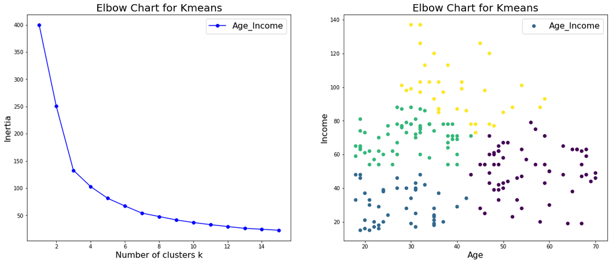

```python
plt.rcParams["figure.figsize"] = (20,8)

plt.subplot(1,2,1)
plt.plot(range(1,k_range+1),data['age_income'], marker='o',color='blue')

plt.legend(['Age_Income'], fontsize=16)
plt.title('Elbow Chart for Kmeans',fontsize=20)
plt.ylabel('Inertia',fontsize=16)
plt.xlabel('Number of clusters k',fontsize=16)



plt.subplot(1,2,2)
plt.scatter(x='Age', y='Income', data = customers, c = kmeans_ai_final_labels )


plt.legend(['Age_Income'], fontsize=16)
plt.title('Elbow Chart for Kmeans',fontsize=20)
plt.ylabel('Income',fontsize=16)
plt.xlabel('Age',fontsize=16)
```

This plot is not extremly insightful (that was the case for the 3D version as well). $K$ has been chosen according to the elbow plot on the left-hand side. What we can recognize is that we have customers of all ages and in all income levels, with the vast majority of them being in the mid and low income. However, as we can see, the cluster boundaries are not very robust, and there are not many natural clusters formed.

### 4.2.2 Elbow Chart for Age-Score

```python
kmeans_as_final = KMeans(n_clusters= 6, n_init=100)
kmeans_as_final.fit(age_score)
kmeans_as_final_labels = kmeans_as_final.labels_
```

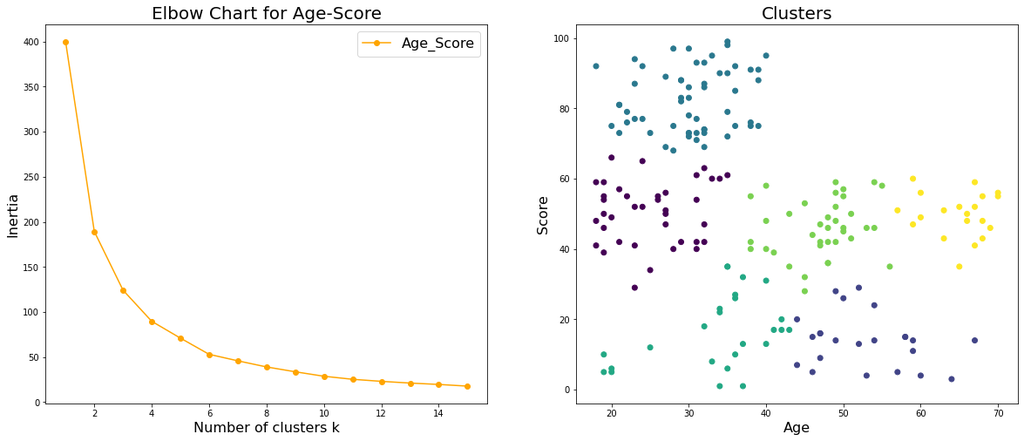

```python
plt.rcParams["figure.figsize"] = (20,8)

plt.subplot(1,2,1)
plt.plot(range(1,k_range+1),data['age_score'], marker='o',color='orange')

plt.legend(['Age_Score'], fontsize=16)
plt.title('Elbow Chart for Age-Score',fontsize=20)
plt.ylabel('Inertia',fontsize=16)
plt.xlabel('Number of clusters k',fontsize=16)



plt.subplot(1,2,2)
plt.scatter(x = 'Age', y = 'Score', data = customers, c = kmeans_as_final_labels)


plt.title('Clusters',fontsize=20)
plt.ylabel('Score',fontsize=16)
plt.xlabel('Age',fontsize=16)
```

### 4.2.3 Elbow Chart for Income-Score

```python
kmeans_is_final = KMeans(n_clusters= 5, n_init=100)
kmeans_is_final.fit(income_score)
kmeans_is_final_labels = kmeans_is_final.labels_
```

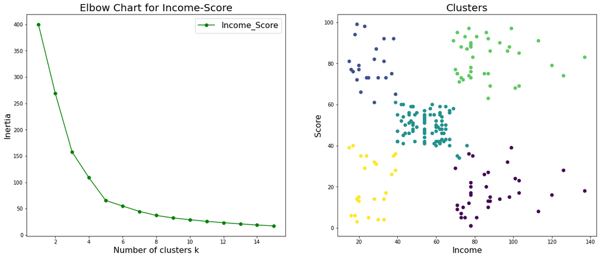

```python
plt.subplot(1,2,1)
plt.plot(range(1,k_range+1),data['income_score'], marker='o',color='green')

plt.title('Elbow Chart for Income-Score',fontsize=20)
plt.legend(['Income_Score'], fontsize=16)
plt.ylabel('Inertia',fontsize=16)
plt.xlabel('Number of clusters k',fontsize=16)


plt.subplot(1,2,2)
plt.scatter(x = 'Income', y = 'Score', data = customers, c = kmeans_is_final_labels)


plt.title('Clusters',fontsize=20)
plt.ylabel('Score',fontsize=16)
plt.xlabel('Income',fontsize=16)
```

# 5. Gender

We first want to get an idea of the male-female ratio in our customer database. In the one-hot encoding procedure, 1=male and 0=female. We can get percentage of females with the following code snippet.

```python
customers_sc_df['Gender'] = customers['Gender']
customers_sc_df['Gender'] = pd.get_dummies(customers_sc_df['Gender'], drop_first=True)
```

```python
print(round((1-sum(customers_sc_df['Gender'].values)/len(customers_sc_df))*100,2), '% of customers are females')
```

```
56.0 % of customers are females
```

## 5.1 2D scatter plots including Gender

```python
# import visualisation library
import seaborn as sns
```

### 5.1.1 Create gender markers

```python
gender_markers = []
for i in customers_sc_df['Gender'].values:
    if i == 1:
        gender_markers.append('x')
    else:
        gender_markers.append('o')
```

### 5.1.2 Three 3 subplots

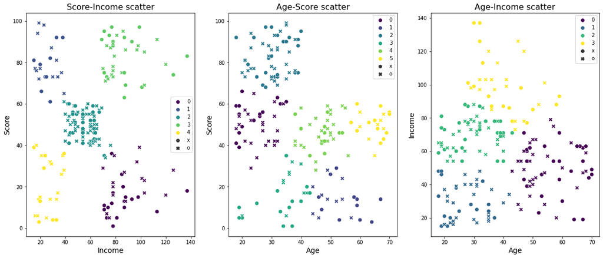

```python
plt.rcParams["figure.figsize"] = (20,8)

plt.subplot(1,3,1)
sns.scatterplot(data=customers, x='Income', y ='Score', s=60, palette= 'viridis', style= gender_markers, hue = kmeans_is_final_labels)
plt.title('Score-Income scatter',fontsize=16)
plt.ylabel('Score',fontsize=14)
plt.xlabel('Income',fontsize=14)

plt.subplot(1,3,2)
sns.scatterplot(data=customers, x='Age', y ='Score', s=60, palette= 'viridis', style= gender_markers, hue = kmeans_as_final_labels)
plt.title('Age-Score scatter',fontsize=16)
plt.ylabel('Score',fontsize=14)
plt.xlabel('Age',fontsize=14)

plt.subplot(1,3,3)
sns.scatterplot(data=customers, x='Age', y ='Income', s=60,  palette= 'viridis', style= gender_markers, hue = kmeans_ai_final_labels )

plt.title('Age-Income scatter',fontsize=16)
plt.ylabel('Income',fontsize=14)
plt.xlabel('Age',fontsize=14)
```

### Additional insight

Overall, female customers are quite *uniformly"* distributed among all cluster segments!

## 5.2 3D scatter plot with Gender

We can also try to visualise the gender feature in the 3D plot, to see if there is additional insight

```python
gender_dict = {0:'o', 1:'x'}
```

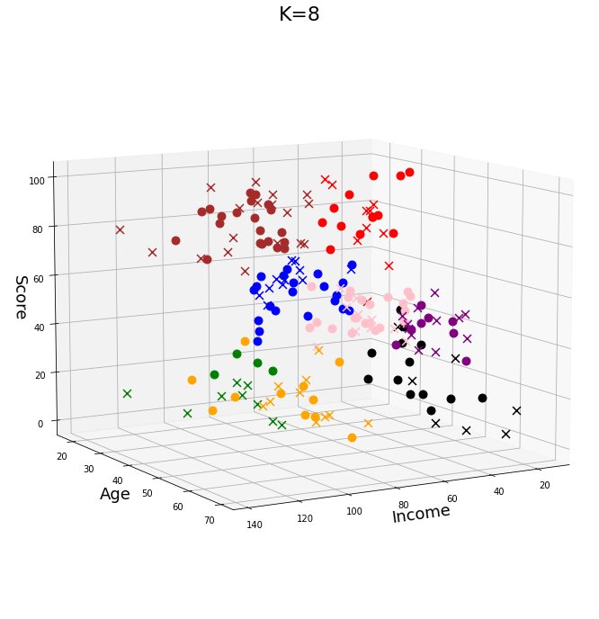

```python
fig3 = plt.figure(figsize=(20,12))
ax3 = fig3.add_subplot(projection='3d')


for i in range(len(labels_8)):

    if i > 7:
        ax3.scatter(Income_8[i], Age_8[i], Score_8[i], c = colors[labels_8[i]] , s=80,
                    marker= gender_dict[customers_sc_df['Gender'][i-8]])

ax3.set_xlabel('Income', fontsize=18)
ax3.set_ylabel('Age', fontsize=18)
ax3.set_zlabel('Score', fontsize=18)
ax3.set_title('K=8', fontsize=22)

ax3.view_init(10,60)
```

## 5.3 Should we include Gender?

The question whether Gender helps identify additional subsegments should be answered with a business case in mind. Overall, given the business cases we have discussed (potential new customer segments/ rewarding good customers), including Gender does not seem to indicate new clusters. This is due to female/male customers being uniformly distributed among most of the clusters. Considering in particular the customer segments of interest, women do not seem to overpopulate either the high scoring/spending or the low scoring - high income clusters. That being said, a company should further investigate whether the products/services consumed by the female population in the high scoring segments are the same with those of the male population. If that is not the case, that is males and females have the same spending profiles, then Gender does not seem to provid additional actionable information. Conversely, if their spending characteristics differ, then further segmentation might be of interest. Differences in preferences could be leveraged in that case both for rewarding high spending female customers and attracting new potential ones.

# 6. Conslusions

Overall, clustering is a process about discovering insights and natrual groupings of data. In the following sections, we summarise the key takeaways from our cluster analysis using $K$-means.

### 6.1 Remarks about $K$-means

Kmeans is an extremely practical and easy to implement clustering technique that can provide, as seen above, very insightful results. While perfoming $K$-means,a few things should be kept in mind. The first is that as it is an unsupervised learning task, there is no single mathematical way to find the best number of clusters. Therefore, one should use domain-specific knowledge, as well as different heuristics (even devise one's own) to determine the "optimal" number of clusters $K$, and always visualise and interpret the resulting clusters. The second is that $K$-means is a heuristic algorithm that converges to local minima. As a result, many initialisations are required to be confident that we get the best possible clusters for a given value of $K$.

### 6.2 Dimensionality Reduction and Visualisation

The 3D visualisation was of immense help in trying to understand the customer segments. By comparing Sections 3 and 4, we clearly showed that taking only two features into account at a time leads to an incomplete understanding of customer segments that could potentially be of interest. However, visualisation is only possible when few features are depicted (3 + some further dimensions depicted with markers, colors and size). Thus, when having too many features about customers, it is perhaps better to first inspect the few most represantitve features (dimensionality reduction) using visualisations, and then sequentially add more features as we did with gender in Section 5.

### 6.3 Business Context

Business context is absolutely vital when doing cluster analysis. As we have demonstrated above with 2 business case studies, the "optimal" number of clusters might vary depending on which segments are of interest to a company. We showed that for identifying and targeting high-Income - low-Score customers, $K$=8 perfoms better, because it subdivides one segment further into two, based on age differences. If we had only followed the elbow method, we would have ended up with one big cluster. For a different business case, another $K$ value could be "optimal".

### 6.4 Curse of dimensionality

$K$-means clustering uses a distance function to measure how close each point is to a centroid. By far the most used distance function for $K$-means is the Euclidean distance. It has been shown, however, that as the number of features increases, all points are quite distant from each other and thus the closest centroid might still be too distant to be considerred *similar*. In such cases, the resulting clusters tend to be less meaningful and interpretable and also, potentially misleading. In this example the maximum number of features is only 4 (so the curse of dimensionality does not necessarily apply), but still we excluded gender from the first analysis round, and included it afterwards to see if it provides additional insight.